# Preliminary Lesson 3: Values

The fundamental data object in R is the **atomic vector**. Atomic vectors form the building block of every other data object that we will use in this course, and in fact any *single* number or word in R is itself an atomic vector of length one. An atomic vector has a **type**, which tells us what kind of values it contains. All values within a single atomic vector must share the same type. An atomic vector can also have a **class**, which affects how R treats the object and may differ from its underlying type.

In this lesson, we will explore four kinds of vectors that you will encounter often in this course: numeric vectors (including the double and integer types), character vectors, factors, and logical vectors. You will learn:

- The difference between double numeric and integer vectors
- How to work with character values, including when single quotes are (and are not) necessary
- What a factor is and why the order of its levels matters
- How logical values are represented and tested, including a common mistake that catches almost everyone at least once

Important! This lesson assumes that you have completed [Preliminary Lesson 2: Environment & Functions](https://evansbrians.github.io/gis_2026/module_0/0.2_environment_and_functions/). The material here builds on that lesson, so please complete it before moving on.

## Before you begin

To get the most out of this lesson, please:

- Open RStudio in a clean session.
- Open a new, blank script file and save it as “lesson_0.3.R”.
- Code along with the content.

## Numbers

R represents the numbers that we will use in this course with two types:

- **Double**: R’s default numeric type, which can represent values with or without a fractional portion.
- **Integer**: A whole number stored with integer type.

Let’s create an atomic vector of numbers and assign it to the name `number_object`:

```r
number_object <-
  c(1, 1, 2, 3)

number_object
```

```
[1] 1 1 2 3
```

We can determine the class of the vector with the `class()` function:

```r
class(number_object)
```

```
[1] "numeric"
```

How an atomic vector is stored in your computer is known as its **type**. We use `typeof()` to determine this:

```r
typeof(number_object)
```

```
[1] "double"
```

Notice that the vector’s class is `"numeric"`, while its type is `"double"`. Unsuffixed numeric values such as `1`, `2`, and `3` are doubles by default – even when they are whole numbers!

True or false: Unsuffixed whole-number values, such as those in `c(1, 1, 2, 3)`, have integer type because they are whole numbers.

To generate an integer vector of adjacent whole numbers, we use the colon function (`:`), which generates a regular sequence from a starting to an ending value:

```r
my_integers <- 1:3

class(my_integers)
```

```
[1] "integer"
```

```r
typeof(my_integers)
```

```
[1] "integer"
```

If we want to generate an integer vector with `c()`, we add an uppercase `L` after each value:

```r
class(
  c(1L, 1L, 2L, 3L)
)
```

```
[1] "integer"
```

We can also convert a double numeric vector to an integer vector with `as.integer()`:

```r
class(
  as.integer(
    c(1, 1, 2, 3)
  )
)
```

```
[1] "integer"
```

`as.integer()` truncates, it does not round!

If you need to preserve the numeric values exactly, only use `as.integer()` when the values are already whole numbers. Otherwise, the conversion changes the values because `as.integer()` truncates rather than rounds. Notice what happens when we convert values with fractional portions to integers:

```r
as.integer(
  c(1.1, 2.3, 5.8)
)
```

```
[1] 1 2 5
```

`as.integer()` truncated (i.e., dropped) the decimal portion of each value rather than rounding to the nearest whole number.

True or false: `as.integer(c(1.1, 2.3, 5.8))` rounds each value to the nearest whole number.

Likewise, we use `as.numeric()` to convert an integer vector to a double numeric vector:

```r
class(
  as.numeric(1:3)
)
```

```
[1] "numeric"
```

```r
typeof(
  as.numeric(1:3)
)
```

```
[1] "double"
```

Test your knowledge!

1. Which of the following produces an atomic vector whose type is integer?

c(1, 2, 3) 1:3 c(1.0, 2.0, 3.0) as.numeric(1:3)

2. Parsons Problem: Reorder the lines below to combine the values 8, 13, and 21 into an object named `my_values`, coerce those values to integer as `my_integers`, then report the type of the result. One line doesn’t belong – leave it in the trash.

### Exercise

Without assigning anything to your global environment, use `c()` to combine the numeric values 8, 13, and 21, and determine the type of the resulting object. Then, convert the values to integers and determine the type of the result again.

This editor won’t auto-indent your code!

Unlike RStudio, the code editor in these practice boxes does not automatically indent your code as you type – pressing Enter after an opening parenthesis will not indent the next line for you the way RStudio does. Get in the habit of indenting your own code as you go here; it’s good practice for when you’re writing real scripts in RStudio, where our [Course style guide](https://evansbrians.github.io/gis_2026/resources/course_style_guide/) rules do apply (and are graded!).

```r
typeof(
  c(8, 13, 21)
)

typeof(
  as.integer(
    c(8, 13, 21)
  )
)
```

What did `as.integer()` change about the values in the exercise above? (Hint: it isn’t how they printed.)

## Characters

A **character vector** stores text strings, which may include letters, numbers, spaces, and punctuation.

When you enter a character value directly in R code, enclose it in quotation marks. The code below creates a character vector and assigns it to the name `months`:

```r
months <-
  c(
    "March",
    "February",
    "January",
    "January"
  )
```

The class and type of a character vector are both `"character"`:

```r
class(months)
```

```
[1] "character"
```

```r
typeof(months)
```

```
[1] "character"
```

Any atomic vector can be converted to a character vector with `as.character()`:

```r
as.character(1:5)
```

```
[1] "1" "2" "3" "4" "5"
```

Which function converts an atomic vector of any class into a character vector?

as.character() as.numeric() typeof() c()

### Single or double quotes?

Single (`'hello world'`) and double (`"hello world"`) quotes can largely be used interchangeably in R. **In this course, we will always use double quotes for character values** – this is the convention set out in our [Course style guide](https://evansbrians.github.io/gis_2026/resources/course_style_guide/) and it matches the [tidyverse style guide](https://style.tidyverse.org/syntax.html#character-vectors).

The main situation in which you will need to reach for single quotes is when the character value itself contains a double quote. Watch what happens when we try to enclose a quoted phrase in double quotes:

```r
"Maude said, "to me they will always be glorious birds""
```

```
Error in parse(text = input): <text>:1:15: unexpected symbol
1: "Maude said, "to
                  ^
```

R reads the second double quote as the *end* of the string, and has no idea what to do with the text that follows. We can resolve this by enclosing the entire value in single quotes instead:

```r
'Maude said, "to me they will always be glorious birds"'
```

```
[1] "Maude said, \"to me they will always be glorious birds\""
```

The reverse problem occurs if a character value contains an apostrophe and is enclosed in single quotes:

```r
'Maude's Cadillac'
```

```
Error in parse(text = input): <text>:1:8: unexpected symbol
1: 'Maude's
           ^
```

Because our course convention is to default to double quotes, this particular problem should rarely come up – but it is worth knowing that the fix is the same in either direction (switch to the other kind of quote) or that you can **escape** the problematic character with a backslash, which tells R to treat the following character literally:

```r
"Maude's Cadillac"
```

```
[1] "Maude's Cadillac"
```

```r
'Maude said, "to me they will always be glorious birds"'
```

```
[1] "Maude said, \"to me they will always be glorious birds\""
```

```r
"Maude said, \"to me they will always be glorious birds\""
```

```
[1] "Maude said, \"to me they will always be glorious birds\""
```

So when *should* I use single quotes?

In this course, use single quotes only when the character value contains a double quote and you choose not to escape that quote. Otherwise, use double quotes – this is one of the rules that our automated style checks will flag!

Test your knowledge!

1. You need a character value that itself contains a double quote. Which approach works?

Enclose the whole value in single quotes, or escape the inner double quote with a backslash There is no way to include a double quote in a string Type two double quotes in a row Remove the inner quote – R does not allow it

2. True or false: in this course, single and double quotes should be used interchangeably, based on whichever you happen to type first.

## Factors

A **factor** is a vector that represents categorical values using integer codes and character levels. A factor contains two pieces of information:

- **Integer values**: An integer code associated with each value.
- **Levels**: The character values associated with each integer code.

*Note: The `factor()` function also has a **labels** argument, which we will use below. Supplying `labels` renames the categories as the factor is created – the new names are then stored as the factor’s levels.*

A factor stores two pieces of information. Which pair correctly names them?

Class and dimension Integer values and levels Names and attributes Rows and columns

Factors are useful when a variable takes one of a limited set of categories (e.g., “juvenile” and “adult”), especially when you care about the order in which those categories are displayed (e.g., “small”, “medium”, “large”).

We create a factor with the `factor()` function, supplying a character vector as the first argument:

```r
example_factor <-
  factor(
    c(
      "one",
      "one",
      "two",
      "three"
    )
  )

class(example_factor)
```

```
[1] "factor"
```

```r
typeof(example_factor)
```

```
[1] "integer"
```

Notice that the type is `"integer"` even though we typed in words!

True or false: A factor is stored in your computer as an integer type, even though you create it by supplying a character vector to `factor()`.

Let’s have a look at the object itself:

```r
example_factor
```

```
[1] one   one   two   three
Levels: one three two
```

There are four values, but they have been grouped into three levels. We can see the integer codes mapped to each level with `as.integer()`:

```r
as.integer(example_factor)
```

```
[1] 1 1 3 2
```

Factor levels are sorted by default!

Notice that “one” was assigned the integer 1, “three” was assigned 2, and “two” was assigned 3. By default, factor levels are sorted – usually alphabetically according to the current locale – rather than ordered by their first appearance in the data. This can cause real problems when a factor’s levels have a natural, non-alphabetical order (e.g., “low”, “medium”, “high”).

True or false: When you create a factor with `factor()` without specifying levels, the levels are ordered according to the order in which the values first appear in the data.

We can plot a factor to see the count of values at each level:

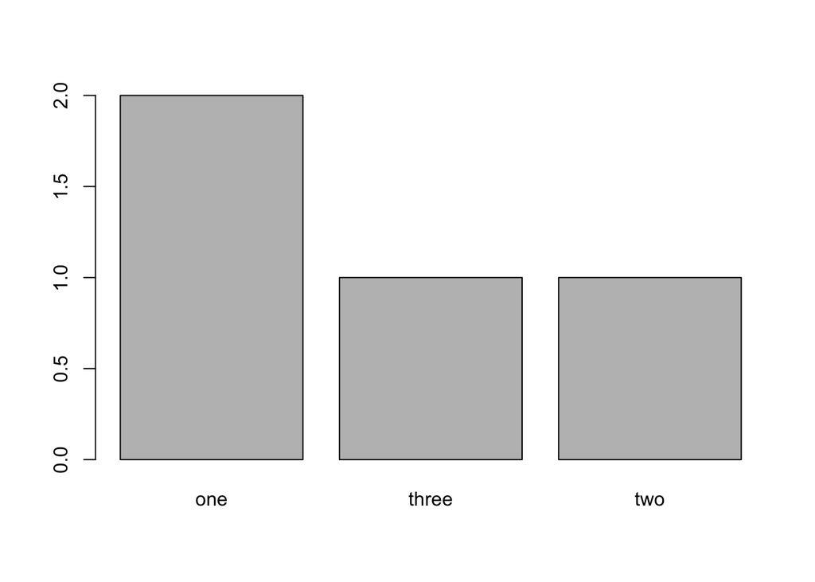

```r
plot(example_factor)
```

Given the x-axis labels, this order doesn’t make a lot of sense. We can manually set the level order with the `levels` argument:

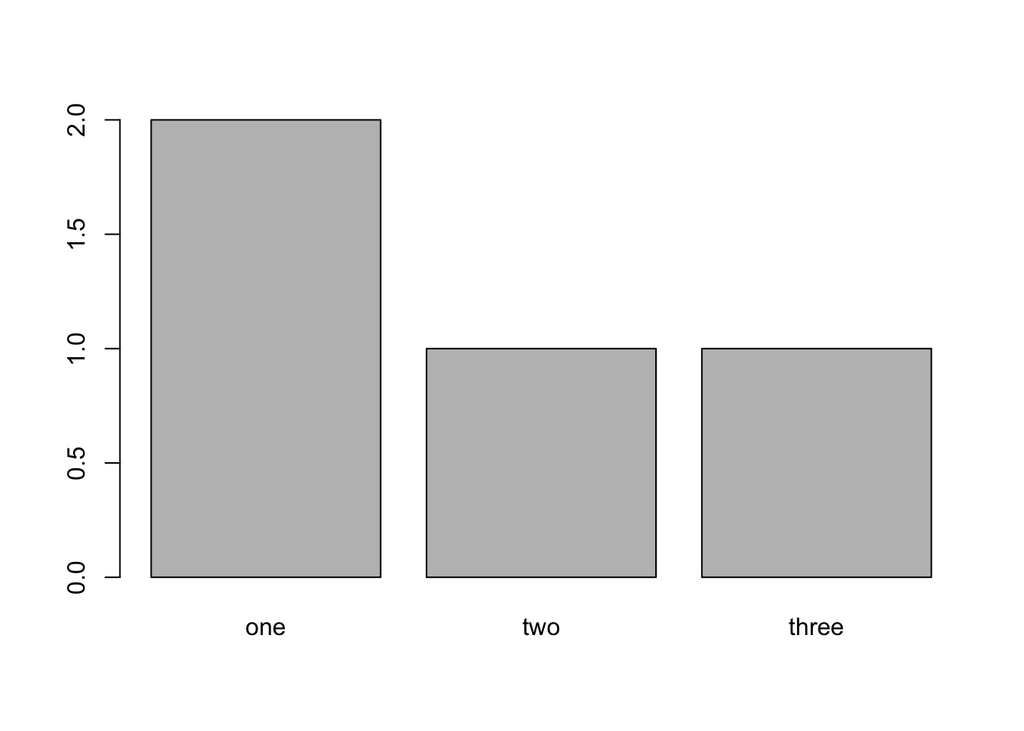

```r
plot(
  factor(
    c("one", "one", "two", "three"),
    levels = c("one", "two", "three")
  )
)
```

Parsons Problem: Reorder and nest the lines below into a call that plots a factor of `"one"`, `"one"`, `"two"`, `"three"` in the order one, two, three. `levels` must end up nested inside `factor()`, which must end up nested inside `plot()`. One line doesn’t belong – leave it in the trash.

We can also relabel the levels (useful for tidier plots) with the `labels` argument, supplied in the order of `levels`:

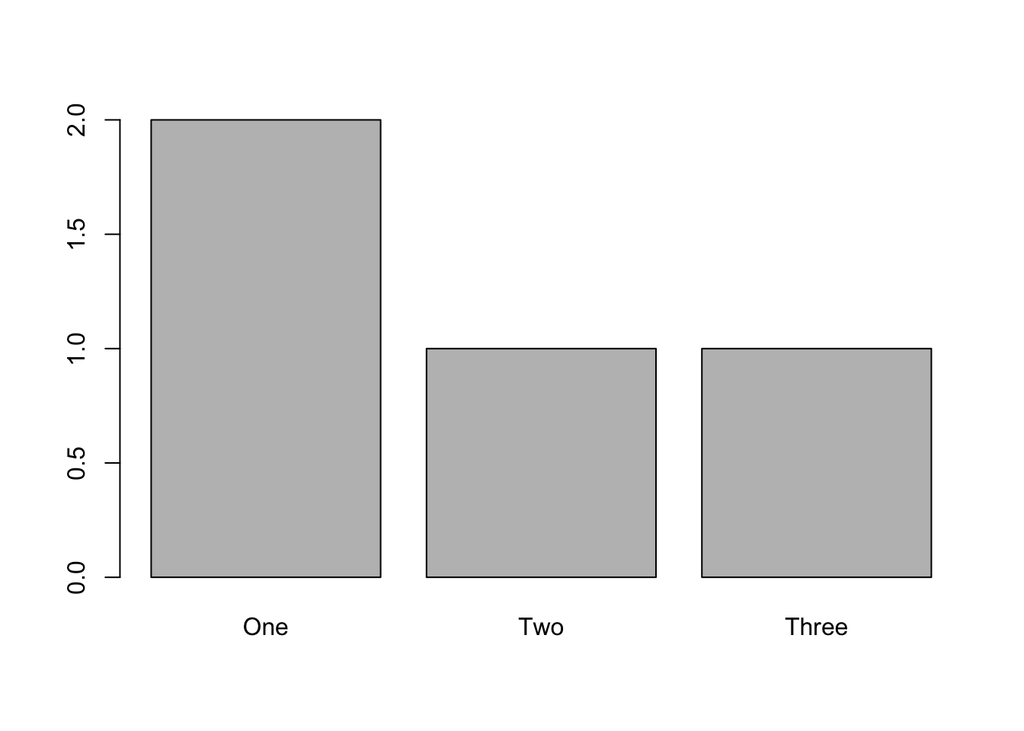

```r
plot(
  factor(
    c("one", "one", "two", "three"),
    levels = c("one", "two", "three"),
    labels = c("One", "Two", "Three")
  )
)
```

Test your knowledge!

1. True or false: The `labels` argument of `factor()` is applied in the order the `levels` are given, so setting `labels` without also setting `levels` can attach a label to the wrong category.
2. Parsons Problem: Extend the previous plot by relabeling the levels “One”, “Two”, “Three”. Inside `factor()`, `levels` must come before `labels`. One line doesn’t belong – leave it in the trash.

### Exercise

Create a factor from the values “low”, “medium”, and “high” (do not assign a name), then repeat with the `levels` argument set so that the values print in order from low to high.

```r
factor(
  c("low", "medium", "high")
)

factor(
  c("low", "medium", "high"),
  levels = c("low", "medium", "high")
)
```

## Logical values

R reserves the words `TRUE` and `FALSE` as **logical constants**. Their type is `"logical"`. When a numeric operation requires numbers, R coerces `FALSE` to 0 and `TRUE` to 1, which means we can evaluate them numerically:

```r
FALSE + TRUE
```

```
[1] 1
```

```r
mean(
  c(FALSE, TRUE)
)
```

```
[1] 0.5
```

True or false: `TRUE` and `FALSE` have logical type, but a numeric operation coerces them to 1 and 0, so `FALSE + TRUE` evaluates to 1.

### Logical operators

We generate logical values by testing an object with a **logical operator**:

| Operator | Usage | Meaning |
| --- | --- | --- |
| `==` | `x == y` | x is equal to y |
| `!=` | `x != y` | x is NOT equal to y |
| `!` | `!(x)` | NOT x |
| `\\|` | `x \\| y` | x OR y |
| `&` | `x & y` | x AND y |
| `%in%` | `x %in% y` | each value of x is found within y |
| `<` | `x < y` | x is less than y |
| `<=` | `x <= y` | x is less than or equal to y |
| `>` | `x > y` | x is greater than y |
| `>=` | `x >= y` | x is greater than or equal to y |

```r
3 < 4
```

```
[1] TRUE
```

```r
3 > 4
```

```
[1] FALSE
```

```r
2:4 == 3
```

```
[1] FALSE  TRUE FALSE
```

Be careful when comparing two sets of values with `==`!

This is one of the most common mistakes that early R users make (we will see it again, applied to data frames, in *Lesson 1.3: R Objects*). Notice what happens when we compare two integer vectors of the same length with `==`:

```r
2:4 == 1:3
```

```
[1] FALSE FALSE FALSE
```

You might expect two of these values to evaluate to `TRUE` – but `==` compares values *by position*, not by set membership. To test whether values in one vector are found *anywhere* in another, use `%in%` instead:

```r
2:4 %in% 1:3
```

```
[1]  TRUE  TRUE FALSE
```

True or false: Comparing two equal-length vectors with `==` tests set membership, so `2:4 == 1:3` returns `TRUE` wherever a value on the left also appears anywhere on the right.

### Exercise

```r
spring %in% summer

summer %in% spring

sum(summer %in% spring)
```

Test your knowledge!

1. Parsons Problem: Reorder the lines below to count how many summer months also occur in spring, wrapping the correct membership test inside `sum()`. One line doesn’t belong – leave it in the trash.
2. Which statement best describes how `%in%` behaves?

It tests for matching values between two vectors, regardless of position or direction It tests whether each value on the left-hand side is found within the right-hand side, so it always produces a result the length of the left-hand side vector It can only be used to compare character vectors It is directionally agnostic: x %in% y and y %in% x return the same result

## Take-home points

Before you move on, here are the ideas from this lesson that are most worth holding onto:

- The **atomic vector** is R’s fundamental object – even a single number or word is a length-one atomic vector – and every value in an atomic vector shares the same **type**. A vector’s **class**, which affects how R treats the object, may differ from its underlying type.
- Unsuffixed numeric values have **double** type by default even when they are whole numbers; use `:` or an `L` suffix (like `1L`) when you actually want **integer**.
- When you need to preserve numeric values exactly, use `as.integer()` only on values that are already whole, because it **truncates** the fractional portion rather than rounding – so `as.integer(2.8)` gives you 2, not 3.
- For characters, default to **double quotes** in this course; single quotes are only needed when the value itself contains a double quote (or you can **escape** that quote with a backslash), and `as.character()` will coerce any vector to character.
- A **factor** represents categorical values using integer codes and character levels, which is why its `typeof()` is integer; unless you say otherwise, its levels are **sorted** – usually alphabetically according to the current locale – rather than ordered by first appearance.
- Take control of a factor with the `levels` argument to set the order and the `labels` argument to rename the categories – and remember `labels` are matched in the order of the `levels`, so setting labels without levels can mislabel a category.
- Logical `TRUE`/`FALSE` are coerced to 1 and 0 in numeric contexts, so you can `sum()` them to count `TRUE`s or take their `mean()` to get a proportion.
- Finally, `==` compares **by position** while `%in%` tests **set membership** – so when you want to know whether values appear *anywhere* in another vector, reach for `%in%`, not `==`.

## Reference

- **Atomic vector**: A one-dimensional, homogeneous data object (a set of values of the same class).
- **Class**: A blueprint that describes an object’s structure.
- **Factor**: A value that maps character labels onto integers.
- **Integer**: A whole number, or an atomic vector of data stored as whole numbers.
- **Labels**: Character values supplied to the labels argument of factor() to rename the levels as a factor is created.
- **Levels**: The character values mapped to a factor’s integer values.
- **Logical operator**: An operator used to test a logical statement (e.g., `3 > 2`).
- **Type**: How an object is stored in your computer.

**Important!** Primitive functions, as well as functions in the packages that R attaches by default (e.g., *base*, *utils*, *stats*, and *graphics*), are available as soon as you start an R session.

| Package | Function | Definition |
| --- | --- | --- |
| .Primitive | + | Infix arithmetic operator (addition) |
| .Primitive | : | Infix operator that generates a regular sequence of adjacent values |
| .Primitive | < | Infix relational operator (less than) |
| .Primitive | <- | Infix operator that assigns an object on the right-hand-side (RHS) to a name on the left-hand-side (LHS) -- this should be used for global assignments! |
| .Primitive | = | Infix operator that assigns an object on the right-hand-side (RHS) to a name on the left-hand-side (LHS) -- this should not be used for global assignments! |
| .Primitive | == | Infix relational operator (is equal to) |
| .Primitive | > | Infix relational operator (greater than) |
| .Primitive | as.character | Transform an atomic vector to a character vector |
| .Primitive | as.integer | Transform an atomic vector to an integer vector |
| .Primitive | as.numeric | Transform an atomic vector to a double numeric vector (i.e., decimal numbers) |
| .Primitive | c | Combine values to form an atomic vector |
| .Primitive | class | Print the class of an object as a one-value character vector |
| .Primitive | sum | Calculate the sum of the values in a numeric vector. |
| base | %in% | Infix relational operator that tests whether the values on the left-hand-side (LHS) are found within the vector on the right-hand-side (RHS) |
| base | factor | Convert a character vector to a factor |
| base | mean | Generate a one-value double numeric vector that describes the mean of a vector |
| base | plot | Generate a basic plot of a data object |
| base | typeof | Print a one-value character vector that represents how a data object is stored on your computer |
| terra | plot | Apply a base R-style plot to a terra raster object |

The most common keyboard shortcuts are provided below for Windows and Mac operating systems.

| Task | Windows | Mac |
| --- | --- | --- |
| View all keyboard shortcuts | Alt + ⇧ + K | ⌥ + ⇧ + K |
| Open an existing script | Ctrl + O | ⌘ + O |
| Create a new script | Ctrl + ⇧ + N | ⌘ + ⇧ + N |
| Save script file | Ctrl + S | ⌘ + S |
| Execute code | Ctrl + Enter | ⌘ + Return |
| Copy | Ctrl + C | ⌘ + C |
| Paste | Ctrl + V | ⌘ + V |
| Add a pipe operator | Ctrl + ⇧ + M | ⌘ + ⇧ + M |
| Add an assignment operator | Alt + dash | ⌥ + dash |
| Add a new code section | Ctrl + ⇧ + R | ⌘ + ⇧ + R |
| Indent code | Ctrl + I | ⌘ + I |